# Week 10 Lecture - Introduction to Experiments

Undergraduate Research Methods in Psychology

Quinton Quagliano, M.S., C.S.P

Department of Psychology

# 1 Week Overview

## 1.1 Learning Objective(s)

- Apply the three criteria for establishing causation to experiments and explain why experiments can support causal claims.
- Identify an experiment’s independent, dependent, and control variables.
- Classify experiments as independent-groups and within-groups designs and explain why researchers might conduct each type of study.
- Evaluate three potential threats to internal validity in an experiment— design confounds, selection effects, and order effects—and explain how experimenters usually avoid them.
- Interrogate an experimental design using the four validities.

## 1.2 Week Overview

- Experiments are bold investigations that are supportive of causal claims.
- They tell us about direct influence that one variable has upon another
- They also tend to be the most rigorous and difficult studies, with lots of required resources

# 2 Experimental Variables

## 2.1 Overview

- Experiments will have at least one measured variable and at least one manipulated variable
- *Example (from the first test):* Changing pillow type (manipulated variable) results in change in sleep quality (measured variable)
- **Discuss: What word in the prior example should really cue you to this being a casual claim?**
- *Review:* a manipulated variable is one that we can directly influence and change, to have a hypothesized impact on our measured variables
- *Review:* measured variables will be things like self-reports or observational measures

## 2.2 Independent & Dependent

- An **independent variable** is one that we can change “independent” of other factors, i.e., it does not depend on something else
  - The manipulated variable
  - It levels (i.e., possible values) are called conditions
- A **dependent variable** is one that is somehow hypothesized to be connected to or reliant upon the condition or state of the independent variable
  - The measured variable
  - It may also be referred to as an outcome variable, similar to a multiple regression design
- Often, the independent variable will be categorical/grouped and the dependent variable will be continuous - but this is not a hard and fast rule
- **Question: I am looking at whether depression symptoms are improved more by psychotherapy or medication treatments - what construct is being treated as dependent?**
- A) Depression symptoms
- B) Medication
- C) psychotherapy
- D) None of these

## 2.3 Control

- **Control variables** are those that are intentionally held at the same level across participants, to prevent it from having an impact on the outcome
- **Discuss: What do we call some value that does not change values in our data?**
- The purpose of keeping these still is to effectively isolate the effect of the independent variable(s), so that it does not confound our causal link.
- *Example:* I am looking at whether more exercise leads to an increase in energy. However, I suspect that caffeine level could confound this relationship, so I instruct participants to not take any caffeine. Caffeine level across participants is consistently 0, therefore it is a control variable and constant.
- **Question: What do we call a variable that interferes with internal validity, like in the prior example?**
- A) A sample
- B) A covariate
- C) A third variable
- D) A criterion

# 3 Why are Experiments Causal?

## 3.1 Overview

- *Review:* Recall our three causal criteria
  - Covariance
  - Temporal precedence
  - Internal validity
- Finally, with experiments we have a method by which to definitively establish all of these

## 3.2 Covariance

- If our separate conditions see differences in the outcome variable (i.e., mean differences on a continuous outcome), we would say there is covariance between the independent and dependent variables
- We have to distinguish what conditions we may assign or manipulate participants to:
  - **Comparison groups:** We have at least two conditions or levels in our independent variable, so that we can compare them
- **Question: What source of information did we explicitly say lacks comparison groups, early in the semester?**
- A) Research
- B) Personal experience
- C) Authority
- D) Intuition
- We may use specific labels for types of comparison groups:
  - **Control group:** One that receives no or minimal intervention
  - **Treatment group:** One that receives the intervention or change of interest
  - **Placebo group:** A type of control, that is exposed to an inert or inactive treatment
- Covariance is equally as important as the other causal criteria $\rightarrow$ no difference between conditions = no causation
- *Example:* I try two different teaching styles between classes to deliver a particular lesson. I take a test at the end of the class on the content. If there is a difference in test scores between the teaching styles, there is covariance.

## 3.3 Temporal Precedence

- By changing the independent variable prior to measuring the dependent variable, we establish that it came prior and that we have temporal precedence.
- We will discuss how exactly to implement time in our discussions on the design types shortly

## 3.4 Internal Validity

- This is the most critical and core feature that sets experiments apart from other designs, and satisfies the last criteria for causality
- Put simply, we must rule out other reasonable and theoretically-salient explanations for the effects that we see in the outcome variable
- **Confounding variables/confounds:** Those that offer alternative explanation for the effects seen in an outcome.
  - Often we will try to control possible confounding variables
  - When a confound results from poor planning in the research design $\rightarrow$ **design confound** $\rightarrow$ poor internal validity
- Experiments can implement design controls that prevent confounds.
- **Discuss: Previously, we discussed a design that gives a statistical control, in contrast to the design control we discuss now - what design was that, and in what context did that control work?**

### Variability

- **Systematic Variability** is when a confound changes in a consistent a predictable manner *with* the independent variable
- **Unsystematic Variability** is when a confound changes in some way separate or indifferent to the independent variable. It may occur in a seemingly random fashion.
  - The result is that there may be variability in the outcome, but if it happens equivalently across all the conditions, it is not as much a concern.
- **Discuss: Based on our discussions in this lecture so far, which of these seems worse for us, and why?**

### Selection Effects

- **Selection Effects** occur when there is systematic variance of some factor across the conditions of the independent variable
  - This ends up being a confound $\rightarrow$ is the change in outcome due to this variance of a third variable or because of the condition? We don't know
  - *Example:* In a treatment study on memory treatments, we assign some people to treatment A and some to treatment B. However, the group with treatment A comprises of mostly older individuals, whereas group B is mostly younger. Age may play a role in resulting memory impairment.
- This can be largely prevented by using **random assignment**, where members of the sample are sort at random into conditions of the IV
- Using **matched groups** is another method to reduce the threat of selection effects
  - This is where participants are measured on some third variable that may confound and ranked. Then each rank is randomly placed in an alternating group
  - A major difficulty of this method is you must accurately identify what variables should be matched on.

# 4 Independent-groups Design

## 4.1 Overview

- **Independent-groups designs** are those in which the participants of each condition are entirely separate from one another
  - A.K.A. as between-subject or between-groups

## 4.2 Posttest-only

- **Posttest-only design:** Separate groups of participants, assigned to different conditions, are measured only after the assignment and intervention has occurred.

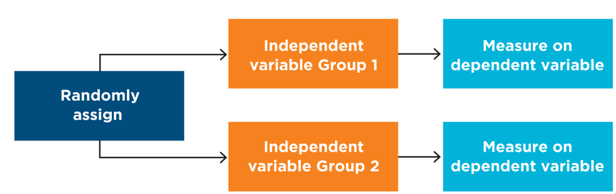

## 4.3 Pretest/Posttest

- **Pretest/Posttest design:** Separate groups are tested on the outcome after the random assignment, but before *and* after the intervention

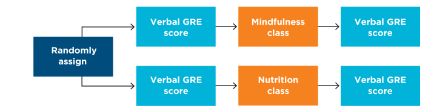

## 4.4 Comparison

- Both the posttest-only and the pretest/posttest designs are perfectly valid experimental designs to investigate causal claims
- The primary difference is:
  - Posttest-only assumes that random assignment produces equivalent groups prior to interdention
  - Pretest/Posttest does not make this assumption and gives measures to validate
- Ideally, pretest/posttest is the “better” design as it provides more validation and data - but we may use posttest-only for practicality
- **Question: I measure a sample of folks on their extraversion and happiness using two continuous measures and then measure them again in a year - what design is this?**
- A) Pretest/Posttest
- B) Bivariate correlational
- C) Posttest-only
- D) Multivariate correlational

# 5 Within-groups Design

## 5.1 Overview

- **Within-groups designs** are when the same group of individuals is exposed to each condition
  - This is in contrast to the separate groups of the prior designs

## 5.2 Repeated Measures

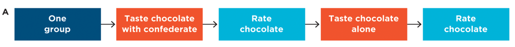

## 5.3 Concurrent Measures

- **Concurrent measures** is when both “conditions” are displayed to the participant at the same time and the measure of interest is some function of the behavior or affect towards the conditions
  - *Review:* Remember Harlow’s monkeys ?
- Depending on the conditions, this may not be a viable strategy

## 5.4 Causal Criteria in Within-Groups

- Do we have covariance?
  - Manipulate and measure two separate variables to see their association
- Do we have temporal precedence?
  - Each measure comes after the intervention or manipulation

### Internal Validity

- Participants control for themselves, i.e., random assignment isn’t necessary
  - Because the individual is the same across conditions, we don’t need to ensure they are equal on some variable like with between groups
- However, we do need to be concerned with **order effects**, where exposure to one condition can have an impact on the next reaction to a different condition
  - **Practice effects:** When someone becomes more skilled at a task due to practice on the prior conditions
  - **Fatigue effects:** When someone becomes less skilled at a task due to tiring from repeated testing
  - **Carryover effects:** When the effect of the previous condition is still residual at the start of the next condition
- **Discuss: Give an example of a situation where you think practice effects could occur on a certain measure**
- Order effects are best prevented by **counterbalancing**, that is assigning some individuals to one order of conditions, and assigning the others to a separate order
  - **Full counterbalancing:** when all possible orders are done
  - **Partial counterbalancing:** when only some possible orders are represented

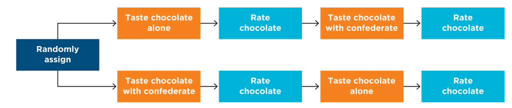

## 5.5 Advantages

- The “groups” are naturally equivalent, as the conditions are tested upon the same individual!
  - I.e., no concern for selection effects, like in between-groups
  - We are able to express a strong control over all the various personal characteristics that could vary unsystematically
- Also requires smaller sample sizes for adequate power

## 5.6 Disadvantages

- As previously discussed, *counterbalancing* is necessary in order to prevent order effects from occurring
- We must attempt to “return” to baseline after each condition - but some interventions may have a permanent or prolonged effect on the participants, confounding the next condition
- We have to contend with the possibility that a participant discovers the hypothesis of a study, by virtue of seeing all the conditions, and changes their behavior in relation to this knowledge.
  - This is called a **demand characteristic**
  - *Review:* This is almost similar to “faking good”, as we discussed with self-report measures
- **Question: What validity is a demand characteristic a threat to?**
- A) Construct validity
- B) Internal validity
- C) External validity
- D) Statistical validity

## 5.7 Pretest-posttest vs Repeated Measures

- The important difference is that whether conditions are applied to different groups or the same people!

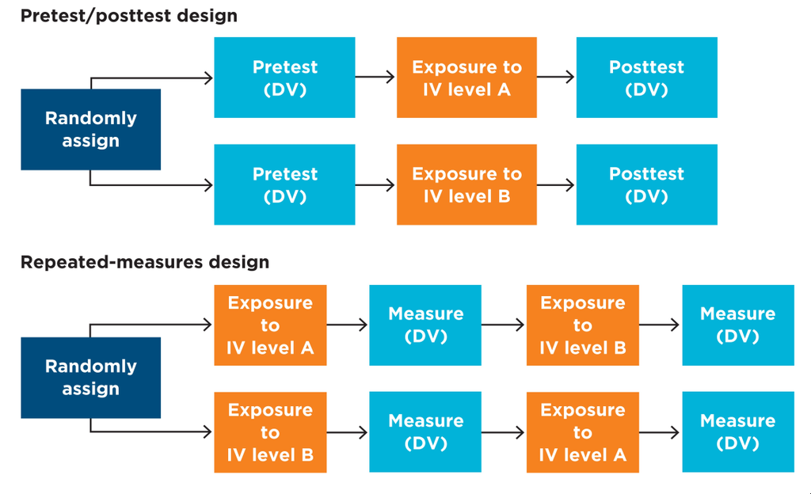

# 6 Four Validities Critique

## 6.1 Construct Validity

- Dependent variables are likely to be assessed the same way we have previously discussed self-report and observational measures.
- **Discuss: What were the 3 primary threats to observational design? Briefly describe them**
- Independent variables are often based, at least initially, on whether they are face valid.
  - We may use a **manipulation check**, or an additional measure meant to ensure that the intervention had the intended effect
  - This can be a good use for a **pilot study**
- All choices of variables to measure and manipulate should be guided by an understanding of the existing theory in the area $\rightarrow$ we must assess whether the variables represent the constructs of the theory well

## 6.2 External Validity

- As previously discussed, sample methodology is the primary factor to consider in whether a sample is representative a specified population, and thus, whether results are generalizable.
- Extrapolating results to other, similar situations, requires additional research
- Typically, experimental research tends to have worse external validity due to tight controls - the results aren’t applicable to “normal” life - but they may be paired with strong correlational designs (i.e., longitudinal or multiple regression) to help with this
- **Discuss: What about sample sizes? What role will they play in external validity or the other validities?**

## 6.3 Statistical Validity

- Just like previous statistical validity discussion, we are concerned with 4 aspects:
  - Effect size : magnitude of effect
  - Precision: What confidence do we have that this effect falls in a narrow range of values
  - Replication: When a study is replicated, are statistics consistent.
  - Significance: Were these results just a fluke of chance?

## 6.4 Internal Validity

- Covered in the previous sections, but this is the key question:
  - “Are the effects found here some methodological error, a third variable, or genuinely the intervention?”

[figure not shown]

Week 10 Lecture - Introduction to Experiments || Undergraduate Research Methods in Psychology